# 6d: sARIMA Fitting

[Nao Mimoto](https://nmimoto.github.io/) - [Dept. of Statistics](http://www.uakron.edu/stat/) : [The University of Akron](http://www.uakron.edu)

[Class Web Page](https://nmimoto.github.io/477/)

## 1. Fit CO2 with Linear Trend + Seasonality

We are using co2 data in TSA package (there’s another one in R)

```r
  # load TSA package while protecting the original acf()
  acf1 = acf
  library(TSA)
  acf = acf1

  data(co2)

  library(forecast)
  source('https://nmimoto.github.io/R/TS-00.txt')

  co2
```

```
##         Jan    Feb    Mar    Apr    May    Jun    Jul    Aug    Sep
## 1994 363.05 364.18 364.87 364.47 364.32 362.13 356.72 350.88 350.69
## 1995 363.49 364.94 366.72 366.33 365.75 364.32 358.59 352.06 353.45
## 1996 366.93 366.71 367.63 368.15 369.14 367.33 361.53 356.11 354.51
## 1997 367.72 369.08 368.17 368.83 369.49 367.57 360.79 355.16 356.01
## 1998 369.40 370.12 370.88 370.53 371.56 369.28 364.50 357.46 360.54
## 1999 372.60 373.85 373.75 374.10 374.50 372.04 364.81 359.11 359.65
## 2000 373.23 375.13 374.83 375.42 376.18 374.01 366.54 360.78 361.77
## 2001 375.49 375.94 376.42 377.48 377.67 374.78 367.38 361.67 363.39
## 2002 376.68 377.42 378.27 378.73 379.01 375.95 370.78 364.07 365.36
## 2003 379.03 379.36 380.90 381.39 382.38 381.02 373.78 367.97 368.55
## 2004 382.44 382.36 381.58 383.21 383.58 382.59 374.58 368.69 368.55
##         Oct    Nov    Dec
## 1994 356.06 360.09 363.27
## 1995 357.27 362.34 365.65
## 1996 360.12 363.85 365.52
## 1997 360.71 364.77 367.81
## 1998 364.04 368.74 371.58
## 1999 364.94 369.82 372.62
## 2000 367.51 370.58 373.37
## 2001 367.74 373.18 374.41
## 2002 370.25 374.04 377.99
## 2003 372.28 377.75 379.99
## 2004 373.39 378.49 381.62
```

```r
  is.ts(co2)        # is it Time Series object?
```

```
## [1] TRUE
```

```r
  frequency(co2)    # is frequency set?
```

```
## [1] 12
```

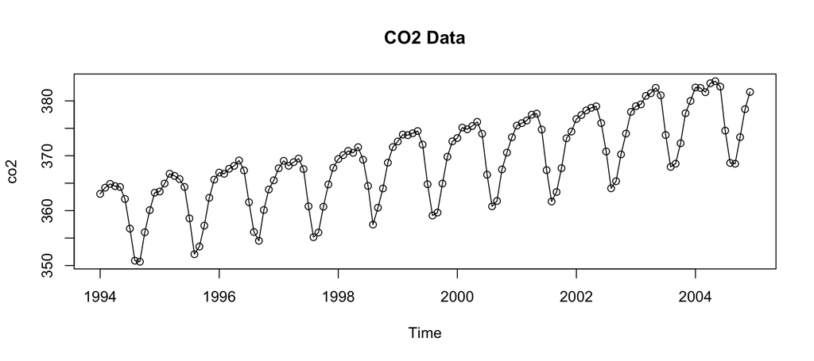

```r
  plot(co2, type="o", main='CO2 Data')
```

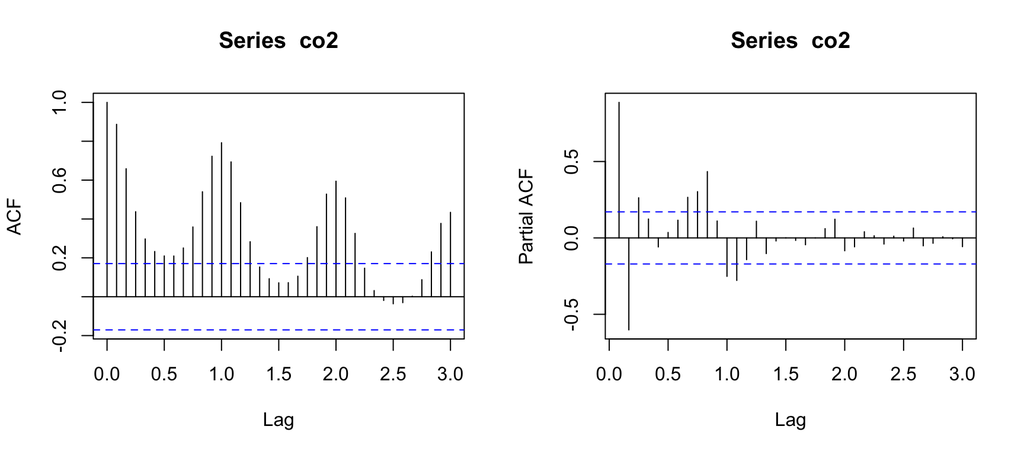

```r
  layout(matrix(1:2, 1,2))
  acf(co2,  lag.max=36)
  pacf(co2, lag.max=36)
```

```r
  layout(1)
```

### 1a. De-seasonalize with Monthly Averages

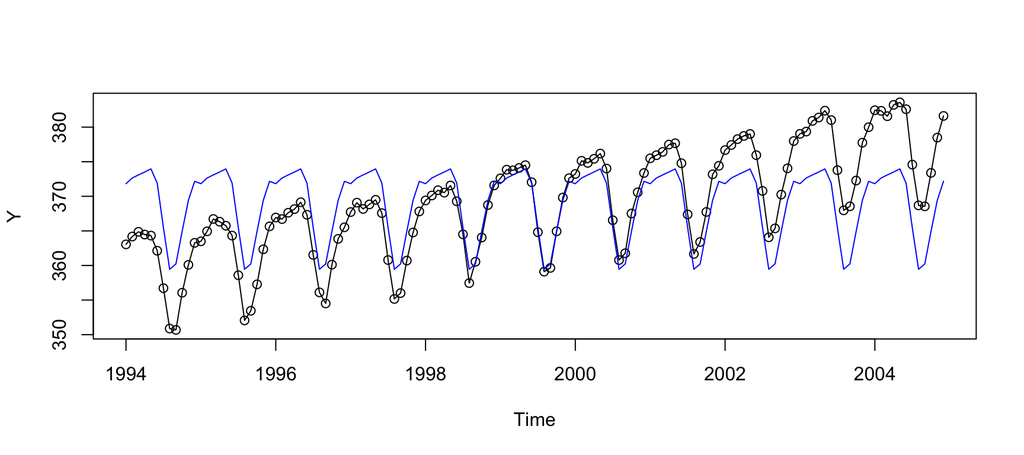

```r
  #--- Take Monthly Averages
  Y = co2
  Mav1  = aggregate(c(Y), list(month=cycle(Y)), mean)$x          #- 1yr long Mtly Av
  Y.MtlyAv = ts(Mav1[cycle(Y)], start=start(Y), freq=frequency(Y))  #- Mtly Av
  Y.DS     = Y-Y.MtlyAv            # Deseasonalized Y

  plot(Y, type="o")               # original
  lines(Y.MtlyAv, col="blue")     # seasonal averages
```

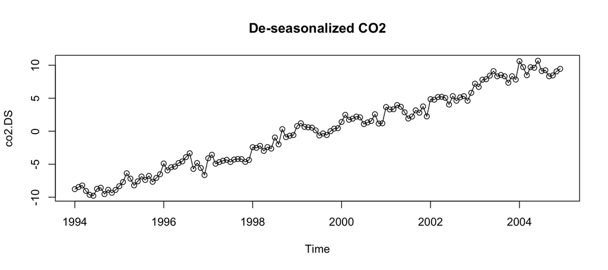

```r
  co2.DS = Y.DS                  # Deseasonalized
  plot(co2.DS, type="o", main="De-seasonalized CO2")
```

### 1b. Fit Line and Check Residuals for Stationarity

```r
  #--- Fit line
  Reg1 = lm(co2.DS ~ time(co2.DS))
  summary(Reg1)
```

```
##
## Call:
## lm(formula = co2.DS ~ time(co2.DS))
##
## Residuals:
##      Min       1Q   Median       3Q      Max
## -2.22331 -0.69056 -0.01021  0.64085  2.36388
##
## Coefficients:
##                Estimate Std. Error t value Pr(>|t|)
## (Intercept)  -3.633e+03  5.112e+01  -71.07   <2e-16 ***
## time(co2.DS)  1.817e+00  2.557e-02   71.07   <2e-16 ***
## ---
## Signif. codes:  0 '***' 0.001 '**' 0.01 '*' 0.05 '.' 0.1 ' ' 1
##
## Residual standard error: 0.9327 on 130 degrees of freedom
## Multiple R-squared:  0.9749, Adjusted R-squared:  0.9747
## F-statistic:  5052 on 1 and 130 DF,  p-value: < 2.2e-16
```

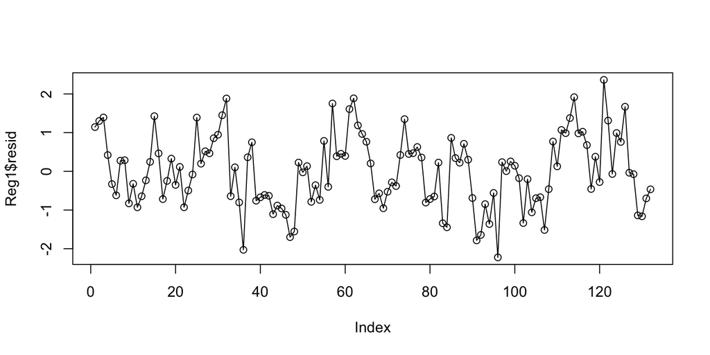

```r
  plot(Reg1$resid, type="o")    # de-seasonalized CO2
  abline(Reg1, col="red")       # plot regression line
```

```r
  Stationarity.tests(Reg1$resid)
```

```
##        KPSS  ADF   PP
## p-val:  0.1 0.02 0.01
```

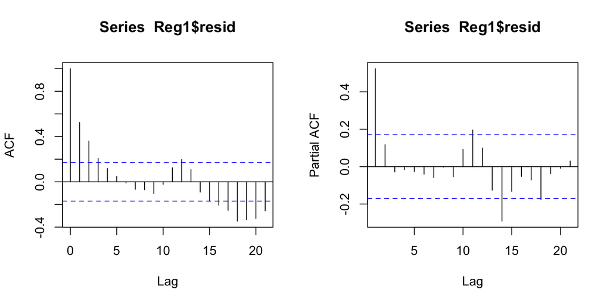

```r
  layout(matrix(1:2, 1,2))
  acf(Reg1$resid)
  pacf(Reg1$resid)
```

```r
  layout(1)
```

### 1c. Fit line + Arma

```r
  Fit11 = auto.arima(co2.DS, d=0, D=0, xreg=time(co2.DS),
                               stepwise=FALSE, approximation=FALSE)
  Fit11
```

```
## Series: co2.DS
## Regression with ARIMA(2,0,0)(2,0,0)[12] errors
##
## Coefficients:
##          ar1     ar2    sar1    sar2   intercept    xreg
##       0.3855  0.2622  0.2462  0.2003  -3624.1376  1.8126
## s.e.  0.0852  0.0891  0.0901  0.0927    150.3886  0.0752
##
## sigma^2 = 0.5676:  log likelihood = -148.18
## AIC=310.36   AICc=311.26   BIC=330.54
```

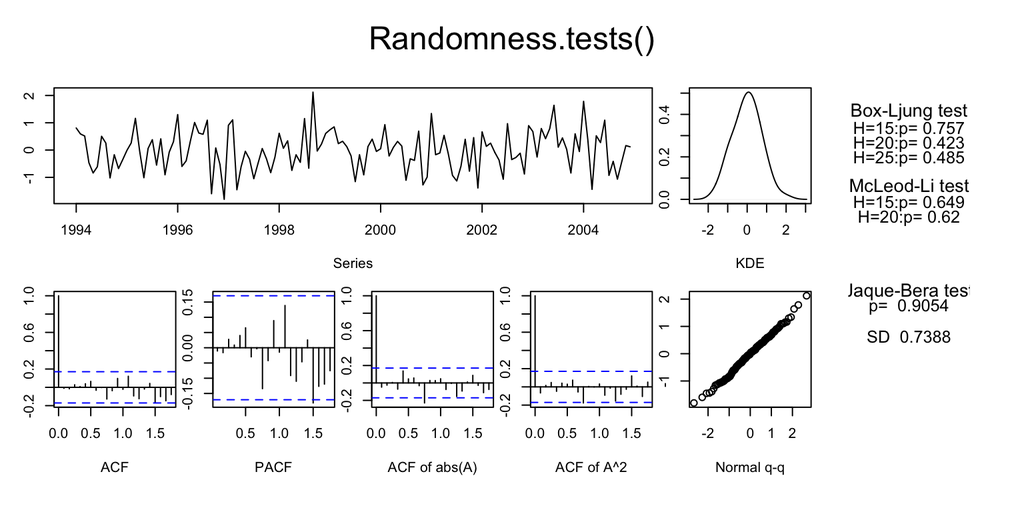

```
##   B-L test H0: the series is uncorrelated
##   M-L test H0: the square of the series is uncorrelated
##   J-B test H0: the series came from Normal distribution
##   SD         : Standard Deviation of the series
```

```
##       BL15  BL20  BL25  ML15 ML20    JB    SD
## [1,] 0.757 0.423 0.485 0.649 0.62 0.905 0.739
```

```r
  Randomness.tests(Fit11$resid)
```

### 1d. Linear Trend Model for CO2 data

With observation $Y_t$,
$$Y_t \hspace{3mm} = \hspace{3mm} L_t + S_t + X_t$$

We first removed $S_t$ by taking monthly average.

The linear trend is
$$L_t = a + bt$$

Then $X_t$ is modeld by ARMA(2,0) $\times$ (2,0)
$$(1-\phi_1 B-\phi_2 B^2)(1-\Phi_1 B^{12} - \Phi_2 B^{24}) X_t =
\epsilon_t$$
where $\epsilon_t \sim WN(0,\sigma^2).$

```r
  Fit11
```

```
## Series: co2.DS
## Regression with ARIMA(2,0,0)(2,0,0)[12] errors
##
## Coefficients:
##          ar1     ar2    sar1    sar2   intercept    xreg
##       0.3855  0.2622  0.2462  0.2003  -3624.1376  1.8126
## s.e.  0.0852  0.0891  0.0901  0.0927    150.3886  0.0752
##
## sigma^2 = 0.5676:  log likelihood = -148.18
## AIC=310.36   AICc=311.26   BIC=330.54
```

### 1e. 12-step Forecasting

```r
  #- 12-step prediction (without seasonality)
  h = 12
  Y = co2.DS
  Fit00 = Fit11

    Y.pred = forecast(Fit00, h, xreg=last(time(Y))+(1:h)/frequency(Y))
    Y.pred
```

```
##          Point Forecast     Lo 80    Hi 80    Lo 95    Hi 95
## Jan 2005       10.56596  9.600437 11.53149 9.089320 12.04260
## Feb 2005       10.40272  9.367926 11.43751 8.820142 11.98529
## Mar 2005       10.44763  9.339424 11.55583 8.752776 12.14248
## Apr 2005       10.87979  9.743621 12.01595 9.142171 12.61740
## May 2005       11.07817  9.924432 12.23190 9.313683 12.84265
## Jun 2005       11.58095 10.418388 12.74351 9.802965 13.35893
## Jul 2005       11.13942  9.971883 12.30696 9.353824 12.92502
## Aug 2005       11.30046 10.130245 12.47067 9.510772 13.09014
## Sep 2005       11.12820  9.956513 12.29988 9.336261 12.92013
## Oct 2005       11.05218  9.879690 12.22466 9.259014 12.84534
## Nov 2005       11.48858 10.315654 12.66150 9.694746 13.28241
## Dec 2005       11.56966 10.396491 12.74282 9.775455 13.36386
```

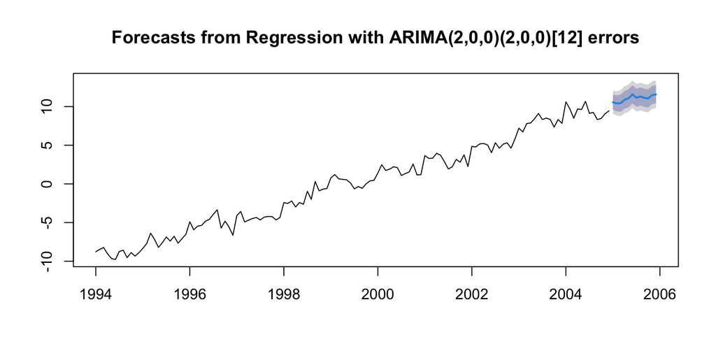

```r
  plot(Y.pred)
```

### 1f. Add back the seasonal average

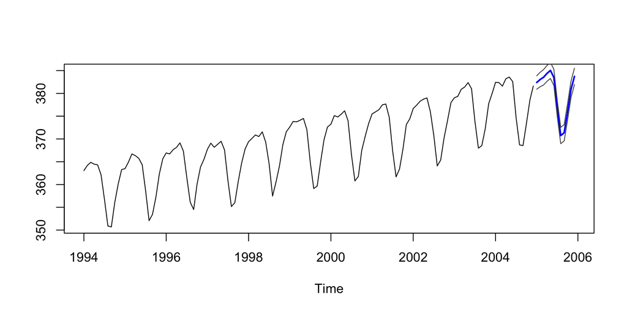

```r
  #--- 12-step prediction w Sesonal average ---
  Y   = co2      # original TS
  Mav = Mav1     # 1yr worth of seasonal average (non ts obj)
  Y.h = Y.pred   # forecat() object

    Yhat     = ts(Y.h$mean     + Mav1, start=last(time(Y))+(1)/frequency(Y), freq=frequency(Y))
    Yhat.CIu = ts(Y.h$lower[,2]+ Mav1, start=last(time(Y))+(1)/frequency(Y), freq=frequency(Y))
    Yhat.CIl = ts(Y.h$upper[,2]+ Mav1, start=last(time(Y))+(1)/frequency(Y), freq=frequency(Y))

    #- Plot the forecast with original data
    ts.plot(Y,Yhat)
    lines( Yhat,     type="l", col="blue", lwd=2)
    lines( Yhat.CIu, type="l", col="gray30", lty=1)
    lines( Yhat.CIl, type="l", col="gray30", lty=1)
```

### 1g. Rolling 1-step Forecasting

[output not shown]

[output cut: 72 more lines]

[output not shown]

```
##
##   Total length 132 , window size 100 .
##   Last 32 obs retrospectively forecasted with Rolling 1-step
##       prediction using same order and fized window size.
##
##   Average Prediction Error:  -1.3566
##   root Mean Squared Error of Prediction:   1.7687
```

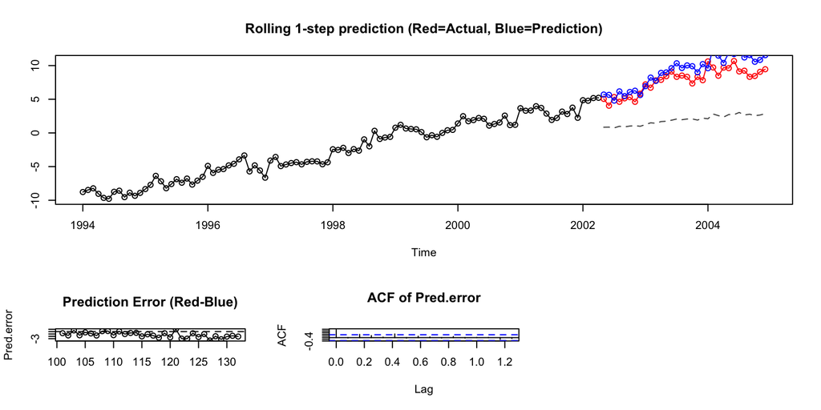

```
## $Actual
##            Jan       Feb       Mar       Apr       May       Jun
## 2002                                          5.048182  4.039091
## 2003  7.206364  6.715455  7.807273  7.877273  8.418182  9.109091
## 2004 10.616364  9.715455  8.487273  9.697273  9.618182 10.679091
##            Jul       Aug       Sep       Oct       Nov       Dec
## 2002  5.325455  4.619091  5.135455  5.312727  4.617273  5.823636
## 2003  8.325455  8.519091  8.325455  7.342727  8.327273  7.823636
## 2004  9.125455  9.239091  8.325455  8.452727  9.067273  9.453636
##
## $Predicted
##            Jan       Feb       Mar       Apr       May       Jun
## 2002                                          5.697850  5.651083
## 2003  6.939824  8.216724  7.718754  8.908150  8.979351  9.608173
## 2004  9.610589 12.678279 11.476297 10.383446 11.892949 11.706710
##            Jul       Aug       Sep       Oct       Nov       Dec
## 2002  4.799410  6.168373  5.464414  6.075324  6.266150  5.625029
## 2003 10.338349  9.642481 10.023891  9.906166  8.990458 10.216002
## 2004 12.915651 11.202170 11.564498 10.558164 10.843491 11.537412
```

```r
  #--- This line will load it to R
  source('https://nmimoto.github.io/R/TS-00.txt')


  #--- Set options (same as above)
  Y = co2.DS                # Original data
  window.size = 100         # Window size for estimation
  Arima.order = c(2,0,0)    # Arima(p,d,q) order
  pred.plot   = TRUE        # do you want plot at end?

  # Arima() options:
  include.mean  = TRUE       #
  include.drift = FALSE      #
  lambda   = NULL            # NULL=no transformaton. 0=Log
  xreg     = TRUE            # NULL=no xreg.  TRUE=Linear Trend is present
  seasonal = c(2, 0, 0)      # seasonal component

    #--- Use the function
    Rolling1step.forecast(Y, window.size, Arima.order, pred.plot,
                          include.mean, include.drift, lambda, xreg, seasonal)
```

```r
  Fit11
```

```
## Series: co2.DS
## Regression with ARIMA(2,0,0)(2,0,0)[12] errors
##
## Coefficients:
##          ar1     ar2    sar1    sar2   intercept    xreg
##       0.3855  0.2622  0.2462  0.2003  -3624.1376  1.8126
## s.e.  0.0852  0.0891  0.0901  0.0927    150.3886  0.0752
##
## sigma^2 = 0.5676:  log likelihood = -148.18
## AIC=310.36   AICc=311.26   BIC=330.54
```

```r
  sqrt(Fit11$sigma2)
```

```
## [1] 0.7534028
```

## 2. Fit CO2 with SARIMA

We fit same CO2 data was fit with SARIMA, and forecasted.

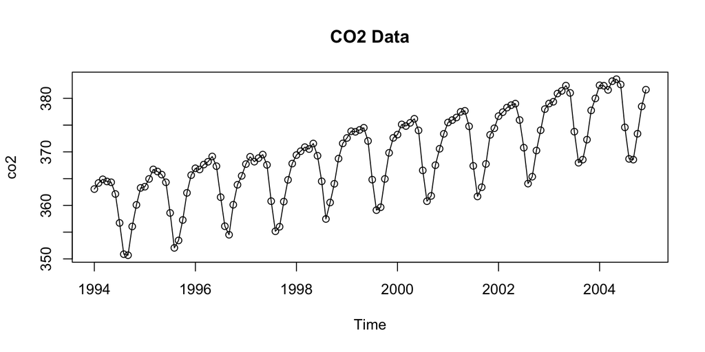

```r
  plot(co2, type="o", main='CO2 Data')
```

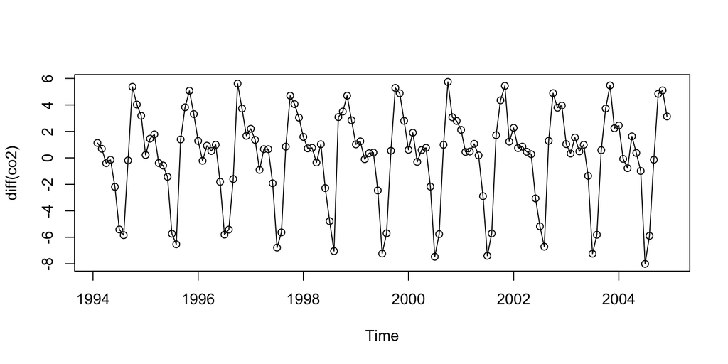

```r
  plot(diff(co2), type="o")
```

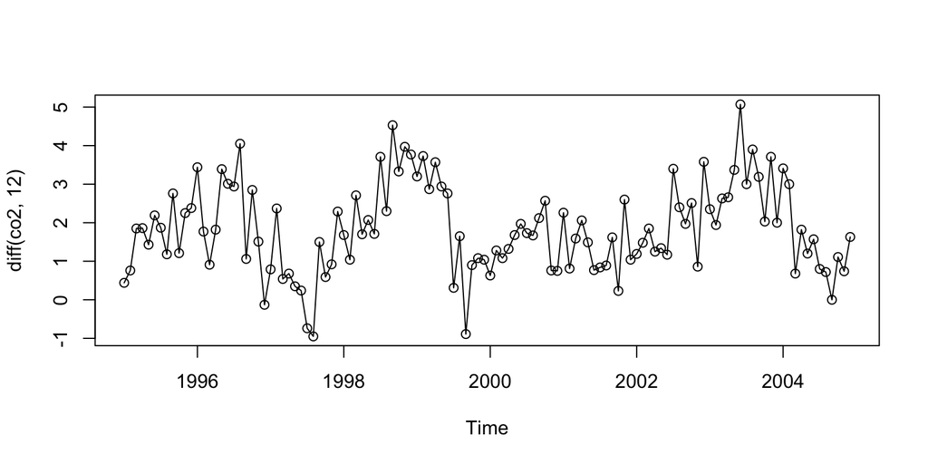

```r
  plot(diff(co2, 12), type="o")
```

```r
  Stationarity.tests( diff(co2,12) )
```

```
##        KPSS   ADF   PP
## p-val:  0.1 0.157 0.01
```

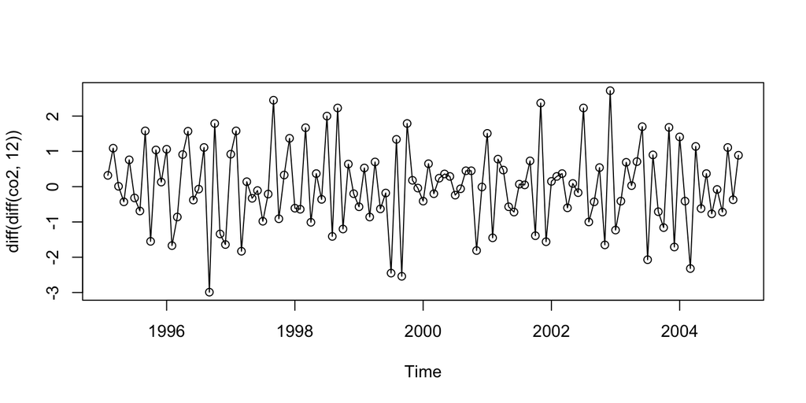

```r
  plot(diff(diff(co2, 12)), type="o")
```

```r
  Stationarity.tests( diff(diff(co2,12)) )
```

```
##        KPSS  ADF   PP
## p-val:  0.1 0.01 0.01
```

As we saw in (7-2) Sec 3, taking a difference does not eliminate the seasonality.

Taking $\bigtriangledown_{12}$, eliminates seasonality, but stationarity is questionable.

$\bigtriangledown \bigtriangledown_{12}$ eliminates seasonlity and produce statonary series.

### 2a. Taking $\bigtriangledown_{12}$

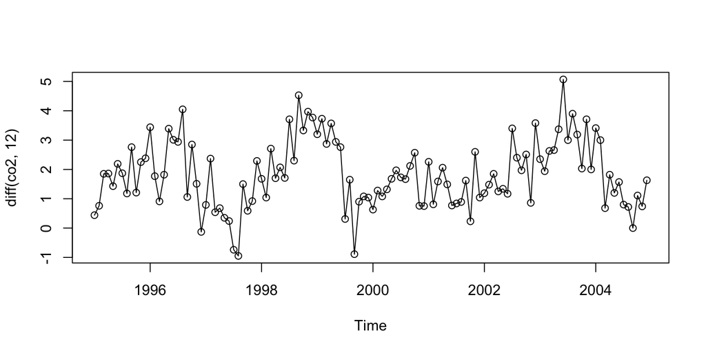

```r
  plot(diff(co2, 12), type="o")
```

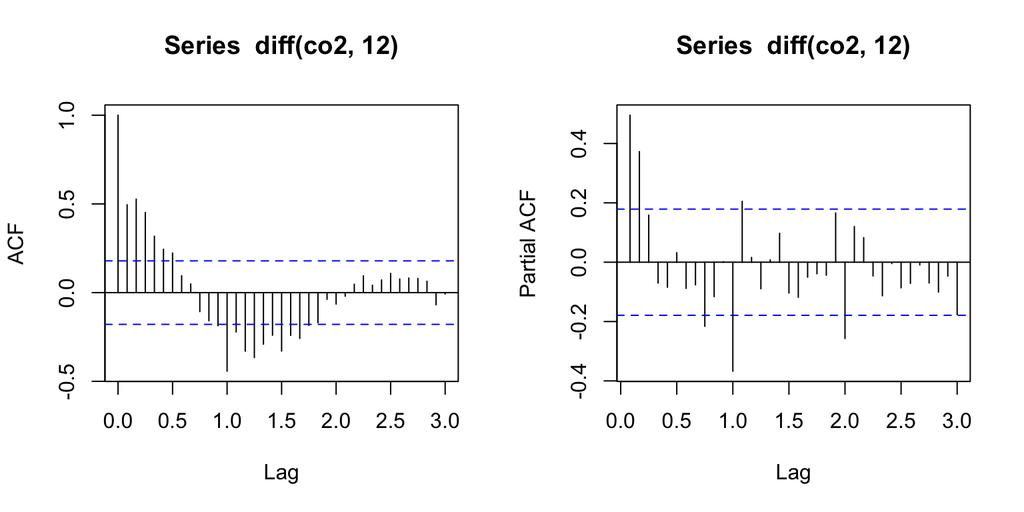

```r
  layout(matrix(1:2, 1, 2))
  acf(diff(co2, 12)  , lag.max=36)
  pacf(diff(co2, 12) , lag.max=36)
```

```r
  layout(1)

  Fit21 = auto.arima(co2, d=0, D=1, stepwise=FALSE, approximation=FALSE)
  Fit21
```

```
## Series: co2
## ARIMA(1,0,1)(0,1,1)[12] with drift
##
## Coefficients:
##          ar1      ma1     sma1   drift
##       0.8349  -0.4630  -0.8487  0.1520
## s.e.  0.0819   0.1246   0.1274  0.0052
##
## sigma^2 = 0.5288:  log likelihood = -136.09
## AIC=282.18   AICc=282.7   BIC=296.11
```

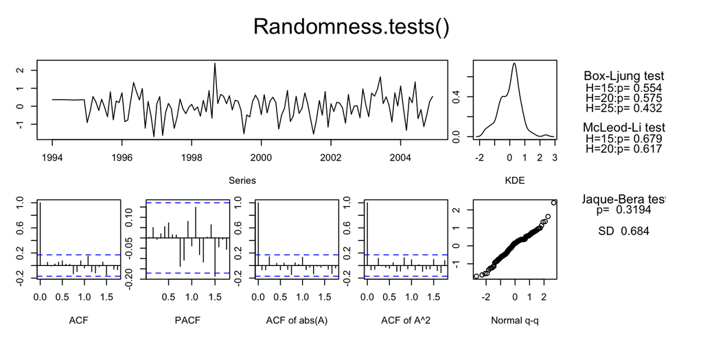

```
##   B-L test H0: the series is uncorrelated
##   M-L test H0: the square of the series is uncorrelated
##   J-B test H0: the series came from Normal distribution
##   SD         : Standard Deviation of the series
```

```
##       BL15  BL20  BL25  ML15  ML20    JB    SD
## [1,] 0.554 0.575 0.432 0.679 0.617 0.319 0.684
```

```r
  Randomness.tests(Fit21$residuals)
```

```r
  Fit21b = Arima(co2, order=c(1,0,1), seasonal=c(0,1,1), include.drift=TRUE )
  Fit21b
```

```
## Series: co2
## ARIMA(1,0,1)(0,1,1)[12] with drift
##
## Coefficients:
##          ar1      ma1     sma1   drift
##       0.8349  -0.4630  -0.8487  0.1520
## s.e.  0.0819   0.1246   0.1274  0.0052
##
## sigma^2 = 0.5288:  log likelihood = -136.09
## AIC=282.18   AICc=282.7   BIC=296.11
```

drift estimate is is 0.1520.

12(0.1520) = 1.824, very close to the slope estimate in Linear Trend model. These two models are consistent.

In the Lienar Trend model, after the regression, model was ARMA(2,0) $\times$ (2,0):
$$(1-\phi_1 B-\phi_2 B^2)(1-\Phi_1 B^{12} - \Phi_2 B^{24}) X_t =
\epsilon_t.$$

If this model is true, taking $\bigtriangledown_{12}$ creates SMA(1) with $\Theta_1=1$:
$$\epsilon_t - e_{t-12}$$

### 2b. Comfirming $\epsilon_t$ in Linear Trend Model

```r
  Arima(co2, order=c(0,0,0),  seasonal=c(0,1,1))
```

```
## Series: co2
## ARIMA(0,0,0)(0,1,1)[12]
##
## Coefficients:
##        sma1
##       0.375
## s.e.  0.072
##
## sigma^2 = 3.795:  log likelihood = -250.49
## AIC=504.98   AICc=505.08   BIC=510.56
```

```r
    # sMA(1) not too close to 1

  Arima(co2, order=c(0,0,0),  seasonal=c(0,1,1), include.drift=TRUE)
```

```
## Series: co2
## ARIMA(0,0,0)(0,1,1)[12] with drift
##
## Coefficients:
##          sma1   drift
##       -0.9998  0.1527
## s.e.   0.1653  0.0018
##
## sigma^2 = 0.6634:  log likelihood = -157.82
## AIC=321.64   AICc=321.85   BIC=330
```

```r
    # Now sMA(1) is close to 1
```

Drift has to be included, since it is significant.

This comfirms the right hand side of Lienar Trend model.

### 2c. Check for Random Trend

If co2 has random walk trend instead of linear trend, Fitting MA(11) should result in $\theta_i$ close to 1.

```r
  Arima(co2, order=c(0,0,11), seasonal=c(0,1,0))
```

```
## Series: co2
## ARIMA(0,0,11)(0,1,0)[12]
##
## Coefficients:
##          ma1     ma2     ma3     ma4     ma5     ma6     ma7     ma8
##       0.7503  0.5927  0.6235  0.7815  0.8266  0.8043  0.8355  0.8013
## s.e.  0.1028  0.1221  0.1157  0.1170  0.1113  0.1368  0.1101  0.1189
##          ma9    ma10    ma11
##       0.6169  0.4684  0.7954
## s.e.  0.1208  0.1151  0.0955
##
## sigma^2 = 0.6845:  log likelihood = -150.54
## AIC=325.08   AICc=328   BIC=358.53
```

```r
    # most of MA(11) pretty close to 1s

  Arima(co2, order=c(0,0,11), seasonal=c(0,1,0), include.drift=TRUE)
```

```
## Series: co2
## ARIMA(0,0,11)(0,1,0)[12] with drift
##
## Coefficients:
##          ma1     ma2     ma3     ma4     ma5     ma6     ma7     ma8
##       0.3972  0.6207  0.2726  0.7195  0.4868  0.7640  0.4740  0.8061
## s.e.  0.1611  0.1247  0.1690  0.0886  0.1660  0.1241  0.1696  0.1164
##          ma9    ma10    ma11   drift
##       0.1842  0.5929  0.3300  0.1430
## s.e.  0.1883  0.1446  0.2036  0.0371
##
## sigma^2 = 0.6598:  log likelihood = -145.02
## AIC=316.04   AICc=319.48   BIC=352.28
```

```r
    # not many MA is close to 1s
```

Drift has to be included, since it is significant.

This is not a good sign that original **co2** has Random Trend
$$Y_t = W_t + S_t + \epsilon_t$$

### 2d. 12-step Forecasting

```r
  #- 12-step prediction (without seasonality)
  Y.pred = forecast(Fit21, 12)
  Y.pred
```

```
##          Point Forecast    Lo 80    Hi 80    Lo 95    Hi 95
## Jan 2005       382.8990 381.9631 383.8349 381.4677 384.3304
## Feb 2005       383.6062 382.6078 384.6046 382.0793 385.1331
## Mar 2005       383.9971 382.9574 385.0367 382.4070 385.5871
## Apr 2005       384.5739 383.5064 385.6415 382.9413 386.2066
## May 2005       385.0562 383.9697 386.1427 383.3946 386.7179
## Jun 2005       383.0545 381.9549 384.1540 381.3728 384.7361
## Jul 2005       376.3810 375.2725 377.4895 374.6856 378.0763
## Aug 2005       370.3794 369.2647 371.4942 368.6746 372.0843
## Sep 2005       371.1485 370.0295 372.2675 369.4371 372.8599
## Oct 2005       375.8221 374.7002 376.9441 374.1063 377.5380
## Nov 2005       380.4135 379.2896 381.5374 378.6946 382.1324
## Dec 2005       383.1663 382.0411 384.2916 381.4454 384.8872
```

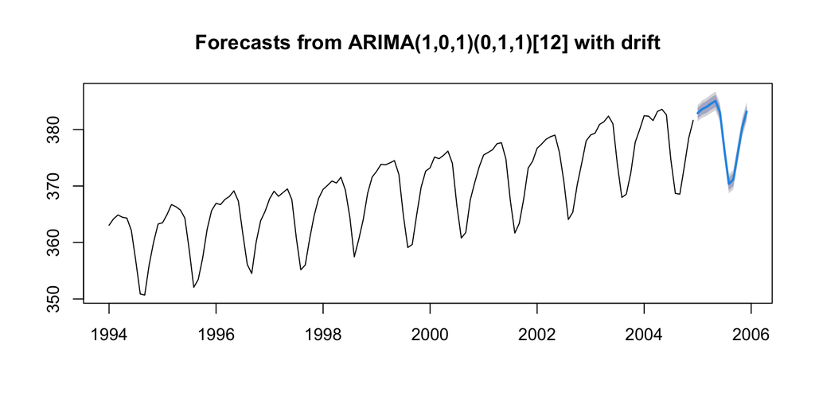

```r
  plot(Y.pred)
```

### 2e. Rolling 1-step Forecasting

[output not shown]

[output cut: 72 more lines]

[output not shown]

```
##
##   Total length 132 , window size 100 .
##   Last 32 obs retrospectively forecasted with Rolling 1-step
##       prediction using same order and fized window size.
##
##   Average Prediction Error:  -1.3566
##   root Mean Squared Error of Prediction:   1.7687
```

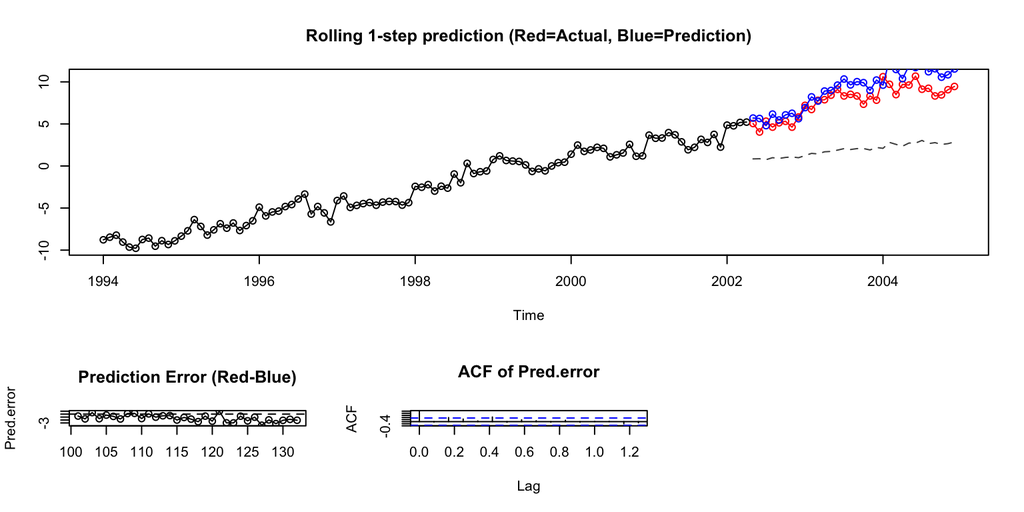

```
## $Actual
##            Jan       Feb       Mar       Apr       May       Jun
## 2002                                          5.048182  4.039091
## 2003  7.206364  6.715455  7.807273  7.877273  8.418182  9.109091
## 2004 10.616364  9.715455  8.487273  9.697273  9.618182 10.679091
##            Jul       Aug       Sep       Oct       Nov       Dec
## 2002  5.325455  4.619091  5.135455  5.312727  4.617273  5.823636
## 2003  8.325455  8.519091  8.325455  7.342727  8.327273  7.823636
## 2004  9.125455  9.239091  8.325455  8.452727  9.067273  9.453636
##
## $Predicted
##            Jan       Feb       Mar       Apr       May       Jun
## 2002                                          5.697850  5.651083
## 2003  6.939824  8.216724  7.718754  8.908150  8.979351  9.608173
## 2004  9.610589 12.678279 11.476297 10.383446 11.892949 11.706710
##            Jul       Aug       Sep       Oct       Nov       Dec
## 2002  4.799410  6.168373  5.464414  6.075324  6.266150  5.625029
## 2003 10.338349  9.642481 10.023891  9.906166  8.990458 10.216002
## 2004 12.915651 11.202170 11.564498 10.558164 10.843491 11.537412
```

```r
  #--- This line will load it to R
  source('https://nmimoto.github.io/R/TS-00.txt')


  #--- Set options (same as above)
  Y = co2.DS                # Original data
  window.size = 100         # Window size for estimation
  Arima.order = c(2,0,0)    # Arima(p,d,q) order
  pred.plot   = TRUE        # do you want plot at end?

  # Arima() options:
  include.mean  = TRUE       #
  include.drift = FALSE      #
  lambda   = NULL            # NULL=no transformaton. 0=Log
  xreg     = TRUE            # NULL=no xreg.  TRUE=Linear Trend is present
  seasonal = c(2, 0, 0)      # seasonal component

    #--- Use the function
    Rolling1step.forecast(Y, window.size, Arima.order, pred.plot,
                          include.mean, include.drift, lambda, xreg, seasonal)
```

```r
  Fit11
```

```
## Series: co2.DS
## Regression with ARIMA(2,0,0)(2,0,0)[12] errors
##
## Coefficients:
##          ar1     ar2    sar1    sar2   intercept    xreg
##       0.3855  0.2622  0.2462  0.2003  -3624.1376  1.8126
## s.e.  0.0852  0.0891  0.0901  0.0927    150.3886  0.0752
##
## sigma^2 = 0.5676:  log likelihood = -148.18
## AIC=310.36   AICc=311.26   BIC=330.54
```

```r
  sqrt(Fit11$sigma2)
```

```
## [1] 0.7534028
```